# Supervised Learning - Foundations Project: ReCell

## Problem Statement

### Business Context

Buying and selling used phones and tablets used to be something that happened on a handful of online marketplace sites. But the used and refurbished device market has grown considerably over the past decade, and a new IDC (International Data Corporation) forecast predicts that the used phone market would be worth \$52.7bn by 2023 with a compound annual growth rate (CAGR) of 13.6% from 2018 to 2023. This growth can be attributed to an uptick in demand for used phones and tablets that offer considerable savings compared with new models.

Refurbished and used devices continue to provide cost-effective alternatives to both consumers and businesses that are looking to save money when purchasing one. There are plenty of other benefits associated with the used device market. Used and refurbished devices can be sold with warranties and can also be insured with proof of purchase. Third-party vendors/platforms, such as Verizon, Amazon, etc., provide attractive offers to customers for refurbished devices. Maximizing the longevity of devices through second-hand trade also reduces their environmental impact and helps in recycling and reducing waste. The impact of the COVID-19 outbreak may further boost this segment as consumers cut back on discretionary spending and buy phones and tablets only for immediate needs.

### Objective

The rising potential of this comparatively under-the-radar market fuels the need for an ML-based solution to develop a dynamic pricing strategy for used and refurbished devices. ReCell, a startup aiming to tap the potential in this market, has hired you as a data scientist. They want you to analyze the data provided and build a linear regression model to predict the price of a used phone/tablet and identify factors that significantly influence it.

### Data Description

The data contains the different attributes of used/refurbished phones and tablets. The data was collected in the year 2021. The detailed data dictionary is given below.

- brand_name: Name of manufacturing brand
- os: OS on which the device runs
- screen_size: Size of the screen in cm
- 4g: Whether 4G is available or not
- 5g: Whether 5G is available or not
- main_camera_mp: Resolution of the rear camera in megapixels
- selfie_camera_mp: Resolution of the front camera in megapixels
- int_memory: Amount of internal memory (ROM) in GB
- ram: Amount of RAM in GB
- battery: Energy capacity of the device battery in mAh
- weight: Weight of the device in grams
- release_year: Year when the device model was released
- days_used: Number of days the used/refurbished device has been used
- normalized_new_price: Normalized price of a new device of the same model in euros
- normalized_used_price: Normalized price of the used/refurbished device in euros

#### Note to reviewer

From time to time, you will find the %%time command included in some cells. It is there because I was interested in knowing the execution time of some cells, especially the cells that generated complex graphics. The command is not critical to the final outcome, but interesting to know.

## Importing necessary libraries

```python
# this will help in making the Python code more structured automatically (good coding practice)
%load_ext nb_black

# Libraries to help with reading and manipulating data
import numpy as np
import pandas as pd

# Libraries to help with data visualization
import matplotlib.pyplot as plt
import seaborn as sns

sns.set()

# split the data into train and test

from sklearn.model_selection import train_test_split

# to build linear regression_model
from sklearn.linear_model import LinearRegression

# to check model performance
from sklearn.metrics import mean_absolute_error, mean_squared_error, r2_score

# to build linear regression_model using statsmodels
import statsmodels.api as sm

# to compute VIF
from statsmodels.stats.outliers_influence import variance_inflation_factor

# disable warnings
import warnings

warnings.filterwarnings("ignore")
```

## Loading the dataset

```python
# read the data
df = pd.read_csv(
    "C:/Users/David/LibreOffice_Personal/DataScience/TestData_Files/used_device_data.csv"
)
# Ran code on local machine using Anaconda

# returns the first 5 rows
df.head()
```

|  | brand_name | os | screen_size | 4g | 5g | main_camera_mp | selfie_camera_mp | int_memory | ram | battery | weight | release_year | days_used | normalized_used_price | normalized_new_price |
| --- | --- | --- | --- | --- | --- | --- | --- | --- | --- | --- | --- | --- | --- | --- | --- |
| 0 | Honor | Android | 14.50 | yes | no | 13.0 | 5.0 | 64.0 | 3.0 | 3020.0 | 146.0 | 2020 | 127 | 4.307572 | 4.715100 |
| 1 | Honor | Android | 17.30 | yes | yes | 13.0 | 16.0 | 128.0 | 8.0 | 4300.0 | 213.0 | 2020 | 325 | 5.162097 | 5.519018 |
| 2 | Honor | Android | 16.69 | yes | yes | 13.0 | 8.0 | 128.0 | 8.0 | 4200.0 | 213.0 | 2020 | 162 | 5.111084 | 5.884631 |
| 3 | Honor | Android | 25.50 | yes | yes | 13.0 | 8.0 | 64.0 | 6.0 | 7250.0 | 480.0 | 2020 | 345 | 5.135387 | 5.630961 |
| 4 | Honor | Android | 15.32 | yes | no | 13.0 | 8.0 | 64.0 | 3.0 | 5000.0 | 185.0 | 2020 | 293 | 4.389995 | 4.947837 |

## Data Overview

- Observations
- Sanity checks

```python
print("There are", df.shape[0], "rows and", df.shape[1], "columns.")
```

```
There are 3454 rows and 15 columns.
```

```python
# Changing the columns 'brand_name' and 'os' into the category data type because that is what they are
# Suggestion from Tasleem

df["brand_name"] = df.brand_name.astype("category")
df["os"] = df.os.astype("category")
```

```python
df.info()
```

```
<class 'pandas.core.frame.DataFrame'>
RangeIndex: 3454 entries, 0 to 3453
Data columns (total 15 columns):
 #   Column                 Non-Null Count  Dtype
---  ------                 --------------  -----
 0   brand_name             3454 non-null   category
 1   os                     3454 non-null   category
 2   screen_size            3454 non-null   float64
 3   4g                     3454 non-null   object
 4   5g                     3454 non-null   object
 5   main_camera_mp         3275 non-null   float64
 6   selfie_camera_mp       3452 non-null   float64
 7   int_memory             3450 non-null   float64
 8   ram                    3450 non-null   float64
 9   battery                3448 non-null   float64
 10  weight                 3447 non-null   float64
 11  release_year           3454 non-null   int64
 12  days_used              3454 non-null   int64
 13  normalized_used_price  3454 non-null   float64
 14  normalized_new_price   3454 non-null   float64
dtypes: category(2), float64(9), int64(2), object(2)
memory usage: 359.2+ KB
```

```python
df.isnull().sum()
```

```
brand_name                 0
os                         0
screen_size                0
4g                         0
5g                         0
main_camera_mp           179
selfie_camera_mp           2
int_memory                 4
ram                        4
battery                    6
weight                     7
release_year               0
days_used                  0
normalized_used_price      0
normalized_new_price       0
dtype: int64
```

```python
df.duplicated().sum()
```

```
0
```

### Observations:

There are no duplicates

```python
df.describe().T
```

|  | count | mean | std | min | 25% | 50% | 75% | max |
| --- | --- | --- | --- | --- | --- | --- | --- | --- |
| screen_size | 3454.0 | 13.713115 | 3.805280 | 5.080000 | 12.700000 | 12.830000 | 15.340000 | 30.710000 |
| main_camera_mp | 3275.0 | 9.460208 | 4.815461 | 0.080000 | 5.000000 | 8.000000 | 13.000000 | 48.000000 |
| selfie_camera_mp | 3452.0 | 6.554229 | 6.970372 | 0.000000 | 2.000000 | 5.000000 | 8.000000 | 32.000000 |
| int_memory | 3450.0 | 54.573099 | 84.972371 | 0.010000 | 16.000000 | 32.000000 | 64.000000 | 1024.000000 |
| ram | 3450.0 | 4.036122 | 1.365105 | 0.020000 | 4.000000 | 4.000000 | 4.000000 | 12.000000 |
| battery | 3448.0 | 3133.402697 | 1299.682844 | 500.000000 | 2100.000000 | 3000.000000 | 4000.000000 | 9720.000000 |
| weight | 3447.0 | 182.751871 | 88.413228 | 69.000000 | 142.000000 | 160.000000 | 185.000000 | 855.000000 |
| release_year | 3454.0 | 2015.965258 | 2.298455 | 2013.000000 | 2014.000000 | 2015.500000 | 2018.000000 | 2020.000000 |
| days_used | 3454.0 | 674.869716 | 248.580166 | 91.000000 | 533.500000 | 690.500000 | 868.750000 | 1094.000000 |
| normalized_used_price | 3454.0 | 4.364712 | 0.588914 | 1.536867 | 4.033931 | 4.405133 | 4.755700 | 6.619433 |
| normalized_new_price | 3454.0 | 5.233107 | 0.683637 | 2.901422 | 4.790342 | 5.245892 | 5.673718 | 7.847841 |

```python
print("There are", df["os"].nunique(), "unique operating systems")
```

```
There are 4 unique operating systems
```

```python
print("Listing of operating system and brand names:")
print(df.groupby(["os"])["brand_name"].value_counts())
print("\nListing of brand names and operating system:")
print(df.groupby(["brand_name"])["os"].value_counts())
```

```
Listing of operating system and brand names:
os
Android  Others        465
         Samsung       323
         Huawei        249
         LG            195
         Lenovo        171
                      ...
iOS      Coolpad         0
         Celkon          0
         BlackBerry      0
         Asus            0
         ZTE             0
Name: brand_name, Length: 136, dtype: int64

Listing of brand names and operating system:
brand_name
Acer        Android     48
            Windows      2
            Others       1
            iOS          0
Alcatel     Android    109
                      ...
Xiaomi      iOS          0
ZTE         Android    139
            Others       1
            Windows      0
            iOS          0
Name: os, Length: 136, dtype: int64
```

```python
# Making backup copy of dataframe

df.to_csv("C:/Users/David/temp/used_device_data_b01.csv", index=False)
```

## Exploratory Data Analysis (EDA)

- EDA is an important part of any project involving data.
- It is important to investigate and understand the data better before building a model with it.
- A few questions have been mentioned below which will help you approach the analysis in the right manner and generate insights from the data.
- A thorough analysis of the data, in addition to the questions mentioned below, should be done.

**Questions**:

1. What does the distribution of normalized used device prices look like?
2. What percentage of the used device market is dominated by Android devices?
3. The amount of RAM is important for the smooth functioning of a device. How does the amount of RAM vary with the brand?
4. A large battery often increases a device's weight, making it feel uncomfortable in the hands. How does the weight vary for phones and tablets offering large batteries (more than 4500 mAh)?
5. Bigger screens are desirable for entertainment purposes as they offer a better viewing experience. How many phones and tablets are available across different brands with a screen size larger than 6 inches?
6. A lot of devices nowadays offer great selfie cameras, allowing us to capture our favorite moments with loved ones. What is the distribution of devices offering greater than 8MP selfie cameras across brands?
7. Which attributes are highly correlated with the normalized price of a used device?

```python
print("There are", df["brand_name"].nunique(), "unique brands")
```

```
There are 34 unique brands
```

```python
print("There are", df.shape[0], "devices total")
```

```
There are 3454 devices total
```

```python
branddf = pd.DataFrame(columns=["Number of Devices", "Percentage"])
branddf["Number of Devices"] = df["brand_name"].value_counts()
branddf["Percentage"] = df["brand_name"].value_counts(normalize=True)

print("Number of devices by brand with percentage of total \n")
print(branddf)

del branddf  # free memory
```

```
Number of devices by brand with percentage of total

            Number of Devices  Percentage
Others                    502    0.145339
Samsung                   341    0.098726
Huawei                    251    0.072669
LG                        201    0.058193
Lenovo                    171    0.049508
ZTE                       140    0.040533
Xiaomi                    132    0.038217
Oppo                      129    0.037348
Asus                      122    0.035321
Alcatel                   121    0.035032
Vivo                      117    0.033874
Micromax                  117    0.033874
Honor                     116    0.033584
HTC                       110    0.031847
Nokia                     106    0.030689
Motorola                  106    0.030689
Sony                       86    0.024899
Meizu                      62    0.017950
Gionee                     56    0.016213
Acer                       51    0.014765
XOLO                       49    0.014186
Panasonic                  47    0.013607
Realme                     41    0.011870
Apple                      39    0.011291
Lava                       36    0.010423
Celkon                     33    0.009554
Spice                      30    0.008686
Karbonn                    29    0.008396
Microsoft                  22    0.006369
OnePlus                    22    0.006369
Coolpad                    22    0.006369
BlackBerry                 22    0.006369
Google                     15    0.004343
Infinix                    10    0.002895
```

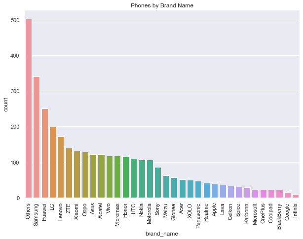

```python
plt.figure(figsize=(10, 7))
plt.title("Phones by Brand Name")
plt.xlabel("Brand Name")
sns.countplot(data=df, x="brand_name", order=df["brand_name"].value_counts().index)
plt.xticks(rotation=90)
```

### Questions:

What percentage of the used device market is dominated by Android devices?

```python
opsysdf = pd.DataFrame(columns=["Number", "Percentage"])
opsysdf["Number"] = df["os"].value_counts()
opsysdf["Percentage"] = df["os"].value_counts(normalize=True)

print("Operating system totals with percentage of total \n")
print(opsysdf)

del opsysdf  # free memory
```

```
Operating system totals with percentage of total

         Number  Percentage
Android    3214    0.930515
Others      137    0.039664
Windows      67    0.019398
iOS          36    0.010423
```

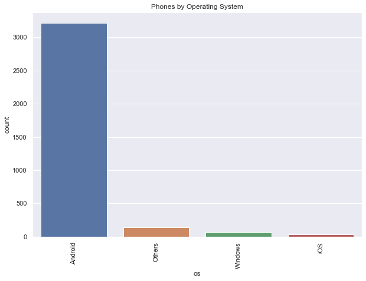

```python
plt.figure(figsize=(10, 7))
plt.title("Phones by Operating System")
plt.xlabel("Operating System")
sns.countplot(data=df, x="os", order=df["os"].value_counts().index)
plt.xticks(rotation=90)
```

### Observations:

93.0515% of the devices run Android. That is pretty much a monopoly.

```python
netdf = pd.DataFrame(
    columns=["4g Number", "4g Percentage", "5g Number", "5g Percentage"]
)
netdf["4g Number"] = df["4g"].value_counts()
netdf["4g Percentage"] = df["4g"].value_counts(normalize=True)
netdf["5g Number"] = df["5g"].value_counts()
netdf["5g Percentage"] = df["5g"].value_counts(normalize=True)

print("Network type totals with percentages \n")
print(netdf)

count4 = netdf.iloc[0,0]
count5 = netdf.iloc[0,2]

del netdf  # free memory
```

```
Network type totals with percentages

     4g Number  4g Percentage  5g Number  5g Percentage
yes       2335       0.676028        152       0.044007
no        1119       0.323972       3302       0.955993
```

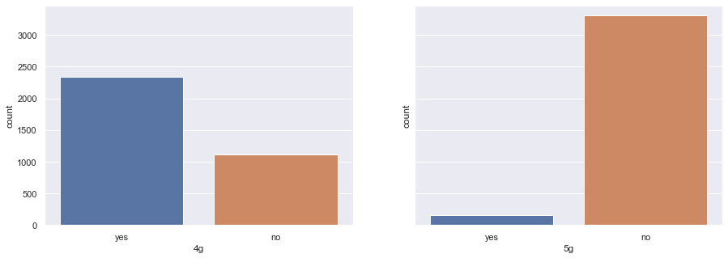

```python
fig, ax = plt.subplots(1, 2, figsize=(15, 5), sharey=True)
sns.countplot(df["4g"], ax=ax[0], order=["yes", "no"])
sns.countplot(df["5g"], ax=ax[1], order=["yes", "no"])
fig.show()
```

### Observations:

The majority of devices are 4g devices which is not a surprise since this is the resale market and 5g devices are the newest models.

```python
diff = df.shape[0] - count4 - count5
print('There are', diff, 'or', round((diff/df.shape[0])*100,2), 'percent devices that are not 4g or 5g devices or devices that cannot communicate over the cell phone network')
```

```
There are 967 or 28.0 percent devices that are not 4g or 5g devices or devices that cannot communicate over the cell phone network
```

```python
print("There are", df["release_year"].nunique(), "unique years")
```

```
There are 8 unique years
```

```python
yeardf = pd.DataFrame(columns=["Year", "Percentage"])
yeardf["Year"] = df["release_year"].value_counts()
yeardf["Percentage"] = df["release_year"].value_counts(normalize=True)


print("Year device released with percentage of total \n")
print(yeardf)
```

```
Year device released with percentage of total

      Year  Percentage
2014   642    0.185871
2013   570    0.165026
2015   515    0.149102
2019   446    0.129126
2016   383    0.110886
2018   322    0.093225
2017   299    0.086566
2020   277    0.080197
```

```python
print(
    "The first three years make up ",
    yeardf.iloc[0:3, 1].sum() * 100,
    "% of the devices.",
    sep="",
)

print(
    "The last three years make up ",
    round((yeardf.iloc[3, 1] + yeardf.iloc[5, 1] + yeardf.iloc[7, 1]) * 100, 2),
    "% of the devices.",
    sep="",
)

del yeardf
```

```
The first three years make up 50.0% of the devices.
The last three years make up 30.25% of the devices.
```

#### Observations:

50% of the available devices were released in 2013-2105. That is the ancient in terms of cell phones and tablets. They are very old and have limited capacity and capability.

Only 30.25% of the devices are from the last three years, 2018-2020, which is not surprizing for the resale market.

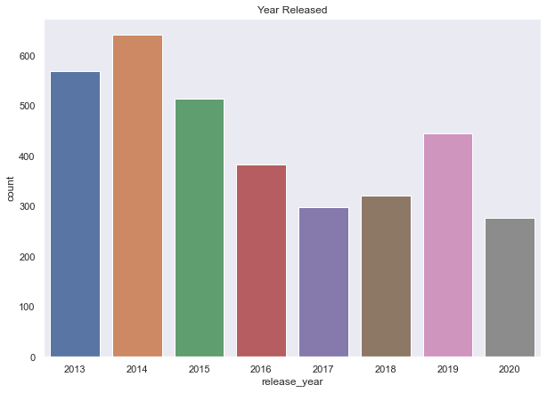

```python
plt.figure(figsize=(10, 7))
plt.grid()
plt.title("Year Released")
sns.countplot(data=df, x="release_year")
```

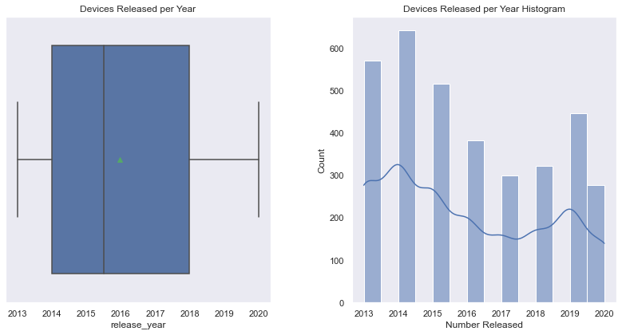

```python
plt.figure(figsize=(17, 6))

plt.subplot(131)
plt.grid()
plt.title("Devices Released per Year")
plt.xlabel("Number Released")
sns.boxplot(data=df, x="release_year", showmeans=True)

plt.subplot(132)
plt.grid()
plt.title("Devices Released per Year Histogram")
plt.xlabel("Number Released")
sns.histplot(data=df, x="release_year", kde=True)

plt.tight_layout(w_pad=5)
```

### Observations:

The distribution is not surprizing as 50% of the devices where released between 2013-2015.

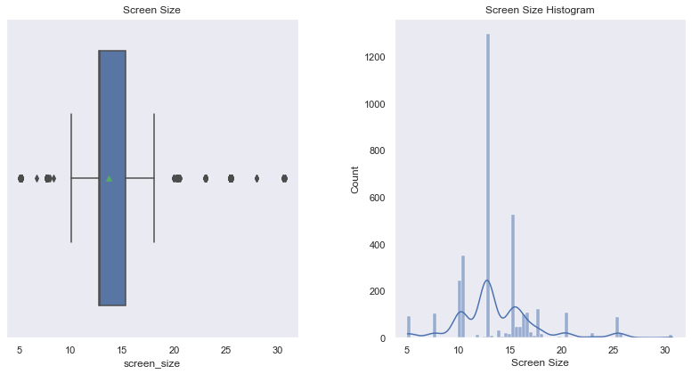

```python
plt.figure(figsize=(17, 6))

plt.subplot(131)
plt.grid()
plt.title("Screen Size")
plt.xlabel("Screen Size")
sns.boxplot(data=df, x="screen_size", showmeans=True)

plt.subplot(132)
plt.grid()
plt.title("Screen Size Histogram")
plt.xlabel("Screen Size")
sns.histplot(data=df, x="screen_size", kde=True)

plt.tight_layout(w_pad=5)
```

### Observations:

Anything but a normal distribution.

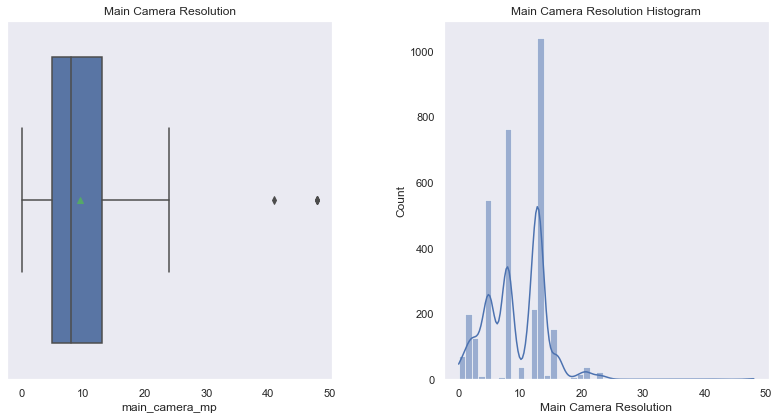

```python
plt.figure(figsize=(17, 6))

plt.subplot(131)
plt.title("Main Camera Resolution")
plt.xlabel("Main Camera Resolution")
sns.boxplot(data=df, x="main_camera_mp", showmeans=True)

plt.subplot(132)
plt.title("Main Camera Resolution Histogram")
plt.xlabel("Main Camera Resolution")
sns.histplot(data=df, x="main_camera_mp", kde=True)

plt.tight_layout(w_pad=5)
```

### Observations:

A right skewed distribution.

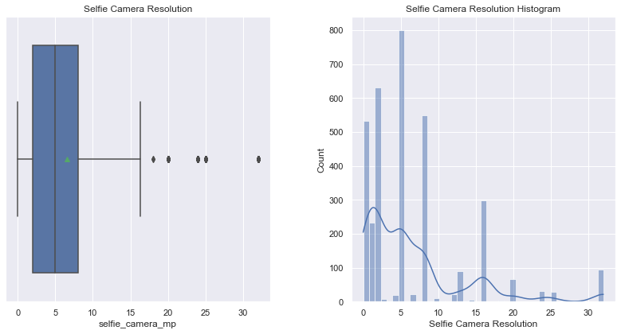

```python
plt.figure(figsize=(17, 6))

plt.subplot(131)
plt.title("Selfie Camera Resolution")
plt.xlabel("Selfie Camera Resolution")
sns.boxplot(data=df, x="selfie_camera_mp", showmeans=True)

plt.subplot(132)
plt.title("Selfie Camera Resolution Histogram")
plt.xlabel("Selfie Camera Resolution")
sns.histplot(data=df, x="selfie_camera_mp", kde=True)

plt.tight_layout(w_pad=5)
```

### Observations:

A right skewed distribution.

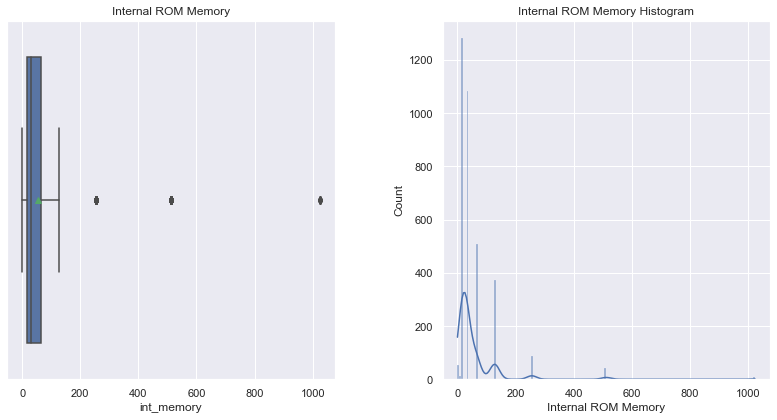

```python
plt.figure(figsize=(17, 6))

plt.subplot(131)
plt.title("Internal ROM Memory")
plt.xlabel("Internal ROM Memory")
sns.boxplot(data=df, x="int_memory", showmeans=True)

plt.subplot(132)
plt.title("Internal ROM Memory Histogram")
plt.xlabel("Internal ROM Memory")
sns.histplot(data=df, x="int_memory", kde=True)

plt.tight_layout(w_pad=5)
```

### Observations:

A very right skewed distribution.

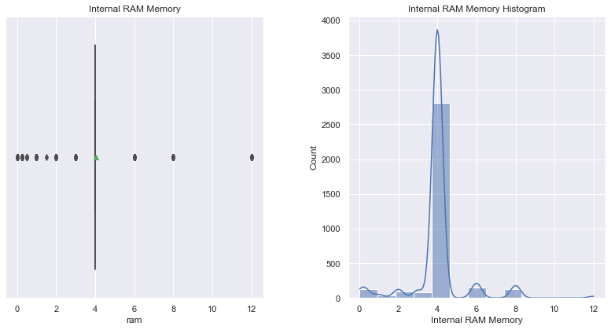

```python
plt.figure(figsize=(17, 6))

plt.subplot(131)
plt.title("Internal RAM Memory")
plt.xlabel("Internal RAM Memory")
sns.boxplot(data=df, x="ram", showmeans=True)

plt.subplot(132)
plt.title("Internal RAM Memory Histogram")
plt.xlabel("Internal RAM Memory")
sns.histplot(data=df, x="ram", kde=True)

plt.tight_layout(w_pad=5)
```

### Observations:

A somewhat normal distribution with a very high middle.

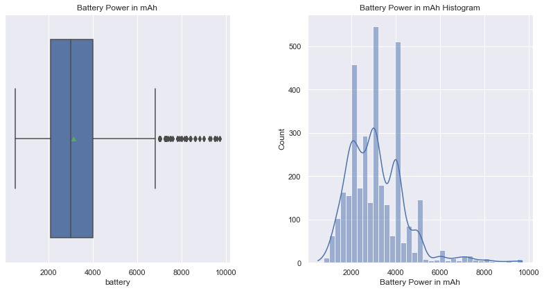

```python
plt.figure(figsize=(17, 6))

plt.subplot(131)
plt.title("Battery Power in mAh")
plt.xlabel("Battery Power in mAh")
sns.boxplot(data=df, x="battery", showmeans=True)

plt.subplot(132)
plt.title("Battery Power in mAh Histogram")
plt.xlabel("Battery Power in mAh")
sns.histplot(data=df, x="battery", kde=True)

plt.tight_layout(w_pad=5)
```

### Observations:

A right skewed distribution.

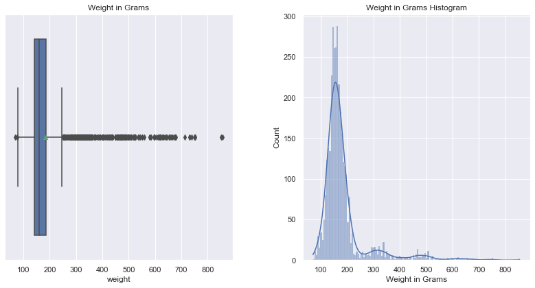

```python
plt.figure(figsize=(17, 6))

plt.subplot(131)
plt.title("Weight in Grams")
plt.xlabel("Weight in Grams")
sns.boxplot(data=df, x="weight", showmeans=True)

plt.subplot(132)
plt.title("Weight in Grams Histogram")
plt.xlabel("Weight in Grams")
sns.histplot(data=df, x="weight", kde=True)

plt.tight_layout(w_pad=5)
```

### Observations:

A very right skewed distribution.

```python
print("Number of days used:")
print(df["days_used"].value_counts())
```

```
Number of days used:
578    13
601    13
564    13
682    12
683    12
       ..
245     1
253     1
269     1
307     1
149     1
Name: days_used, Length: 924, dtype: int64
```

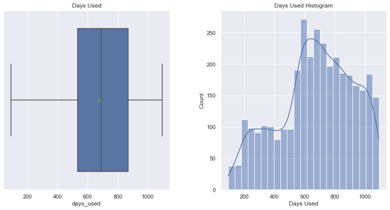

```python
plt.figure(figsize=(17, 6))

plt.subplot(131)
plt.title("Days Used")
plt.xlabel("Days Used")
sns.boxplot(data=df, x="days_used", showmeans=True)

plt.subplot(132)
plt.title("Days Used Histogram")
plt.xlabel("Days Used")
sns.histplot(data=df, x="days_used", kde=True)

plt.tight_layout(w_pad=5)
```

### Observations:

A left skewed distribution.

### Questions:

What does the distribution of normalized used device prices look like?

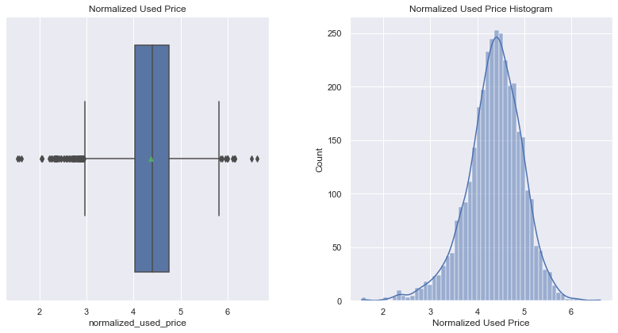

```python
plt.figure(figsize=(17, 6))

plt.subplot(131)
plt.title("Normalized Used Price")
plt.xlabel("Normalized Used Price")
sns.boxplot(data=df, x="normalized_used_price", showmeans=True)

plt.subplot(132)
plt.title("Normalized Used Price Histogram")
plt.xlabel("Normalized Used Price")
sns.histplot(data=df, x="normalized_used_price", kde=True)

plt.tight_layout(w_pad=5)
```

### Observations:

A close to normal distribution.

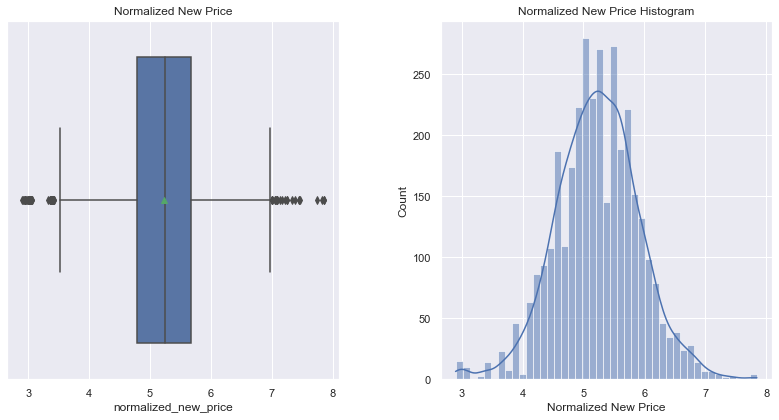

```python
plt.figure(figsize=(17, 6))

plt.subplot(131)
plt.title("Normalized New Price")
plt.xlabel("Normalized New Price")
sns.boxplot(data=df, x="normalized_new_price", showmeans=True)

plt.subplot(132)
plt.title("Normalized New Price Histogram")
plt.xlabel("Normalized New Price")
sns.histplot(data=df, x="normalized_new_price", kde=True)

plt.tight_layout(w_pad=5)
```

### Observations:

A close to normal distribution.

```python
tempdf = df.copy()
tempdf["price_diff"] = tempdf["normalized_new_price"] - tempdf["normalized_used_price"]
```

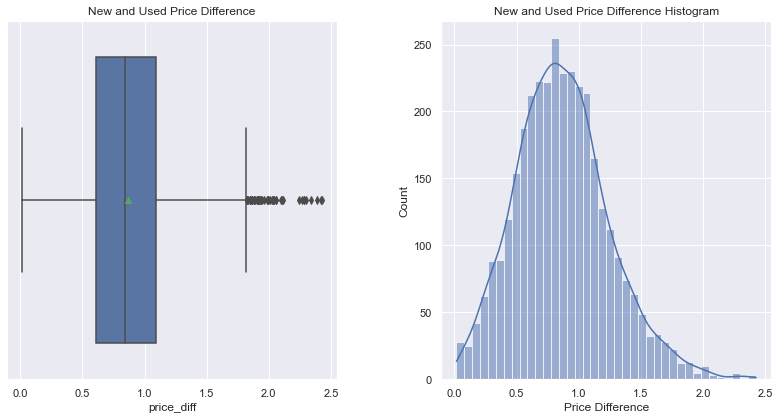

```python
plt.figure(figsize=(17, 6))

plt.subplot(131)
plt.title("New and Used Price Difference")
plt.xlabel("Price Difference")
sns.boxplot(data=tempdf, x="price_diff", showmeans=True)

plt.subplot(132)
plt.title("New and Used Price Difference Histogram")
plt.xlabel("Price Difference")
sns.histplot(data=tempdf, x="price_diff", kde=True)

plt.tight_layout(w_pad=5)
```

```python
tempdf = tempdf.groupby(["brand_name"])["price_diff"].sum()
print("Brands with the lowest difference between new and used price:\n")
print(round(tempdf.sort_values(ascending=True), 2))

del tempdf
```

```
Brands with the lowest difference between new and used price:

brand_name
Infinix         2.64
Microsoft      16.68
Coolpad        16.94
Google         17.88
Realme         20.02
BlackBerry     21.79
Spice          22.76
Karbonn        23.42
OnePlus        24.52
Celkon         25.99
Lava           26.36
Panasonic      37.70
XOLO           43.66
Acer           43.86
Apple          52.06
Meizu          52.11
Gionee         56.23
Honor          79.38
Nokia          80.16
Motorola       81.16
Xiaomi         86.33
Sony           86.98
Micromax       87.98
Vivo          100.61
Alcatel       100.92
Asus          106.98
HTC           114.12
ZTE           119.08
Oppo          119.25
Lenovo        129.77
LG            198.93
Huawei        215.99
Samsung       346.56
Others        440.62
Name: price_diff, dtype: float64
```

### Observations:

Brands where there is a low difference between new and used prices means the devices from those brands when resold will sell at near new prices thereby increasing profit. This is assumed in the absence of the acquisition cost which could change this calculation.

### Questions:

The amount of RAM is important for the smooth functioning of a device. How does the amount of RAM vary with the brand?

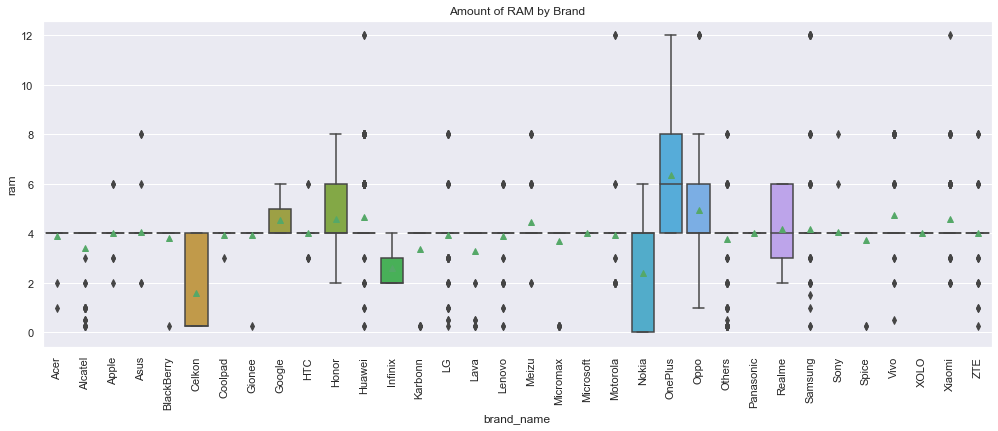

```python
plt.figure(figsize=(17, 6))
plt.title("Amount of RAM by Brand")
plt.xlabel("Amount of RAM by Brand")
plt.xticks(rotation=90)
sns.boxplot(data=df, x="brand_name", y="ram", showmeans=True)
```

### Questions:

A large battery often increases a device's weight, making it feel uncomfortable in the hands. How does the weight vary for phones and tablets offering large batteries (more than 4500 mAh)?

```
There are 341 phones with batteries larger than 4500 mAh

Number of phones with large batteries by brand name:
Samsung       50
Others        41
Huawei        37
Xiaomi        31
Lenovo        28
Asus          22
Apple         17
Honor         14
Motorola      14
Vivo          13
LG            12
Realme        12
ZTE           10
Gionee        10
Acer           7
Sony           6
Infinix        6
Oppo           4
HTC            1
Alcatel        1
Micromax       1
Nokia          1
Panasonic      1
Google         1
Spice          1
BlackBerry     0
XOLO           0
Celkon         0
Lava           0
Coolpad        0
Karbonn        0
OnePlus        0
Microsoft      0
Meizu          0
Name: brand_name, dtype: int64
```

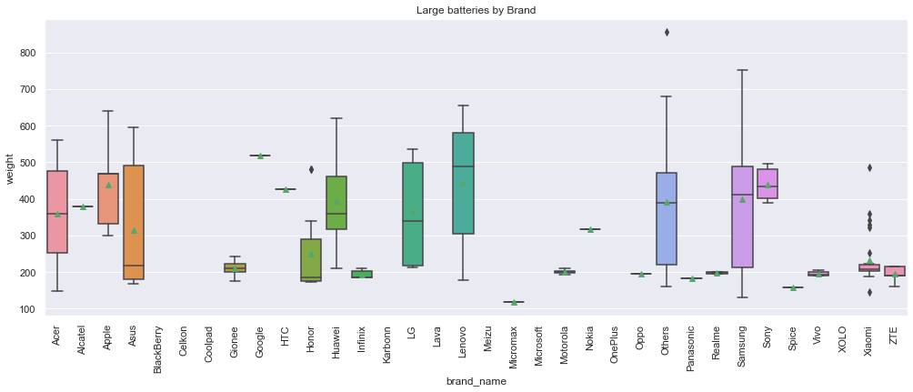

```python
tempdf = df[df.battery > 4500]

print("\nThere are", tempdf.shape[0], "phones with batteries larger than 4500 mAh\n")

print("Number of phones with large batteries by brand name:")
print(tempdf["brand_name"].value_counts())

plt.figure(figsize=(17, 6))
plt.title("Large batteries by Brand")
plt.xlabel("Large batteries by Brand")
plt.xticks(rotation=90)
sns.boxplot(data=tempdf, x="brand_name", y="weight", showmeans=True)

del tempdf  # free memory
```

### Observations:

The number of devices with large batterues is all over the place. Only 14 brands have some type of distribution of the size of the battery. There is no decenable patterm for the other brands.

### Questions:

Bigger screens are desirable for entertainment purposes as they offer a better viewing experience. How many phones and tablets are available across different brands with a screen size larger than 6 inches?

```
There are 1099 phones with screen size larger than 6 inches

Number of phones with screen size larger than 6 inches by brand name:
Huawei        149
Samsung       119
Others         99
Vivo           80
Honor          72
Oppo           70
Lenovo         69
Xiaomi         69
LG             59
Motorola       42
Asus           41
Realme         40
Alcatel        26
Apple          24
Acer           19
Meizu          17
ZTE            17
OnePlus        16
Nokia          15
Sony           12
Infinix        10
Micromax        7
HTC             7
Google          4
XOLO            3
Gionee          3
Coolpad         3
Spice           2
Panasonic       2
Karbonn         2
Microsoft       1
Celkon          0
BlackBerry      0
Lava            0
Name: brand_name, dtype: int64
```

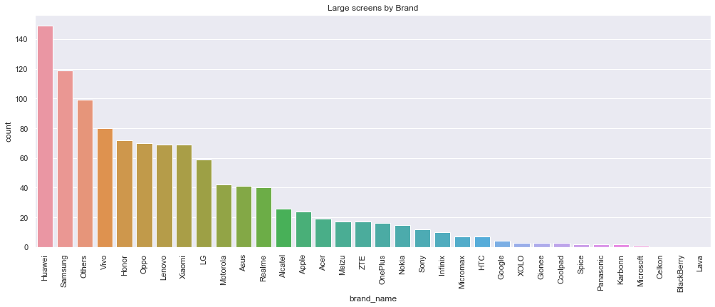

```python
tempdf = df[df.screen_size > 6 * 2.54]

print("\nThere are", tempdf.shape[0], "phones with screen size larger than 6 inches \n")

print("Number of phones with screen size larger than 6 inches by brand name:")
print(tempdf["brand_name"].value_counts())

plt.figure(figsize=(17, 6))
plt.title("Large screens by Brand")
plt.xlabel("Large screens by Brand")
plt.xticks(rotation=90)
sns.countplot(
    data=tempdf, x="brand_name", order=tempdf["brand_name"].value_counts().index
)

del tempdf  # free memory
```

### Questions:

A lot of devices nowadays offer great selfie cameras, allowing us to capture our favorite moments with loved ones. What is the distribution of devices offering greater than 8MP selfie cameras across brands?

[output not shown]

[figure not shown]

```python
tempdf = df[df.main_camera_mp > 8]

print(
    "\nThere are",
    tempdf.shape[0],
    "phones with a selfie camera with a respolution greater than 8 megapixels \n",
)

print(
    "Number of phones with a selfie camera with a respolution greater than 8 megapixels:"
)
print(tempdf["brand_name"].value_counts())

plt.figure(figsize=(17, 6))
plt.title("Selfie Cameras by Brand")
plt.xlabel("Selfie Cameras by Brand")
plt.xticks(rotation=90)
sns.countplot(
    data=tempdf, x="brand_name", order=tempdf["brand_name"].value_counts().index
)

del tempdf  # free memory
```

### Analysis for main or rear camera

```
There are 94 phones with a main camera with a respolution greater than 16 megapixels

Number of phones with a main camera with a respolution greater than 16 megapixels:
Sony          37
Motorola      11
Others         9
HTC            6
Meizu          5
ZTE            5
Nokia          4
Microsoft      4
Asus           3
BlackBerry     2
Samsung        2
Lenovo         1
Xiaomi         1
Panasonic      1
Gionee         1
Acer           1
Honor          1
Alcatel        0
Google         0
XOLO           0
Vivo           0
Spice          0
Apple          0
Celkon         0
Realme         0
Lava           0
Huawei         0
Oppo           0
OnePlus        0
Infinix        0
Karbonn        0
LG             0
Micromax       0
Coolpad        0
Name: brand_name, dtype: int64
```

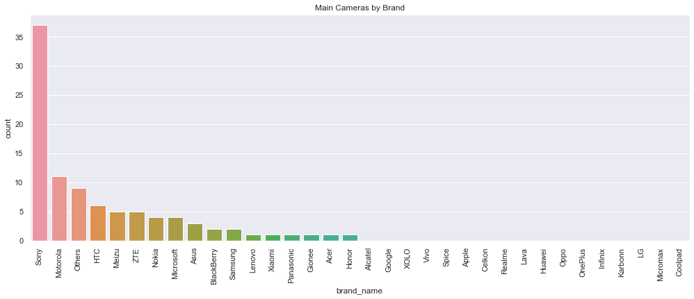

```python
tempdf = df[df.main_camera_mp > 16]

print(
    "\nThere are",
    tempdf.shape[0],
    "phones with a main camera with a respolution greater than 16 megapixels \n",
)

print(
    "Number of phones with a main camera with a respolution greater than 16 megapixels:"
)
print(tempdf["brand_name"].value_counts())

plt.figure(figsize=(17, 6))
plt.title("Main Cameras by Brand")
plt.xlabel("Main Cameras by Brand")
plt.xticks(rotation=90)
sns.countplot(
    data=tempdf, x="brand_name", order=tempdf["brand_name"].value_counts().index
)

del tempdf  # free memory
```

### Observations:

Few devices have high resolution main cameras which is not surprizing given the ages of the devices.

### Questions:

Which attributes are highly correlated with the normalized price of a used device?

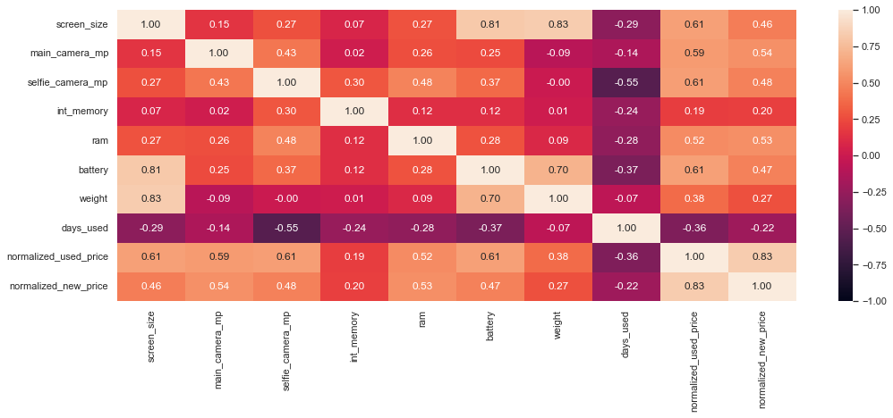

```
Wall time: 398 ms
```

```python
%%time

columns = df.select_dtypes(include=np.number).columns.tolist()
columns.remove("release_year")

plt.figure(figsize=(17, 6))
sns.heatmap(df[columns].corr(), annot=True, vmin=-1, vmax=1, fmt=".2f")
plt.show()
```

### Observations:

The attributes that are highly correlated with the normalized price of a used device:

- normalized_new_price
- battery
- RAM
- main_camera_mp
- selfie_camera_mp
- screen_size

"Highly correlated" defined as values equal to or greater than 0.50 (i.e. 50%)

### Analysis of cost of used phone over the years

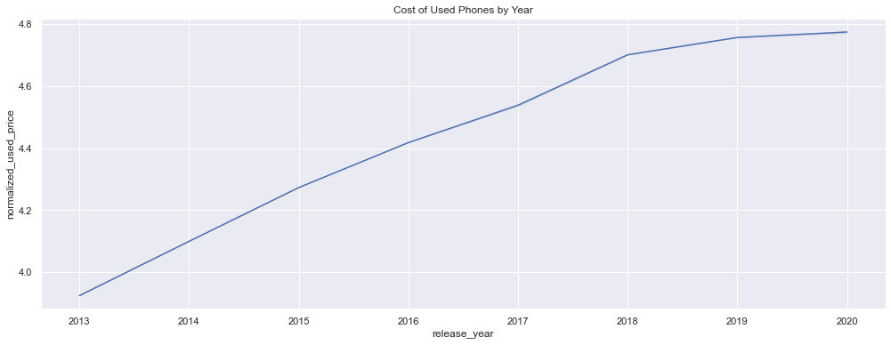

```python
plt.figure(figsize=(17, 6))
plt.title("Cost of Used Phones by Year")
sns.lineplot(
    data=df, x="release_year", y="normalized_used_price", ci=False, markers=True
)
plt.show()
```

### Observations:

The newer phones cost more and the older phones cost less which is not a surprize. There are more older phones and fewer new phones. Basic supply and demand. Also the newer phones will have more feature/functions than the older phones.

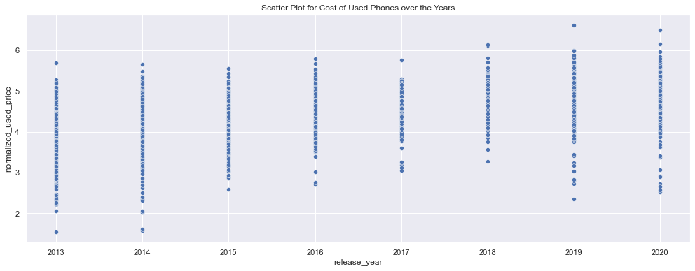

```python
plt.figure(figsize=(17, 6))
plt.title("Scatter Plot for Cost of Used Phones over the Years")
sns.scatterplot(data=df, x="release_year", y="normalized_used_price")
plt.show()
```

### Analysis of cost of used phone over the years by network type

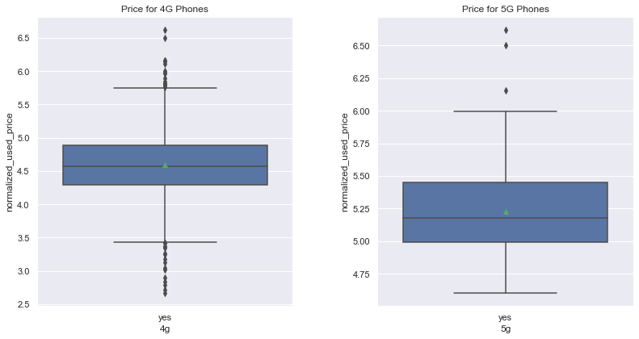

```python
fourdf = df[df["4g"] == "yes"]
fivedf = df[df["5g"] == "yes"]

plt.figure(figsize=(17, 6))

plt.subplot(131)
plt.title("Price for 4G Phones")
plt.xlabel("Price for 4G Phones")
sns.boxplot(
    data=fourdf, x="4g", y="normalized_used_price", showmeans=True,
)

plt.subplot(132)
plt.title("Price for 5G Phones")
plt.xlabel("Price for 5G Phones")
sns.boxplot(
    data=fivedf, x="5g", y="normalized_used_price", showmeans=True,
)

plt.tight_layout(w_pad=5)

del fourdf
del fivedf
```

### Observations:

While the histograms look the same, there are different. The Y scale for 4g is from 2.5 to 6.5 while the Y scale for 5g is from 4.5 to 6.5. There is greater price distribuition on the 4g phones than there is for the 5g phones. The mean cost of the 4g phones is approximately 4.5 while it is approximately 5.20 for 5g.

The only commonality between the two costs is the mean and median are pretty much the same. The median is sightly lower for 5g, but not by much.

```python
# Making backup copy of dataframe

df.to_csv("C:/Users/David/temp/used_device_data_b02.csv", index=False)

# Read command if needed
# df = pd.read_csv("C:/Users/David/LibreOffice_Personal/DataScience/TestData_Files/used_device_data_b02.csv.csv")
```

## Data Preprocessing

- Missing value treatment
- Feature engineering (if needed)
- Outlier detection and treatment (if needed)
- Preparing data for modeling
- Any other preprocessing steps (if needed)

```python
print("Check for Null Values and Percentage of rows that have null values")
pd.DataFrame(
    {
        "Count": df.isnull().sum()[df.isnull().sum() > 0],
        "Percentage": (df.isnull().sum()[df.isnull().sum() > 0] / df.shape[0]) * 100,
    }
)

# Code from file: Hands_on_Notebook_ExploratoryDataAnalysis.ipynb.  I liked the code.
```

```
Check for Null Values and Percentage of rows that have null values
```

|  | Count | Percentage |
| --- | --- | --- |
| main_camera_mp | 179 | 5.182397 |
| selfie_camera_mp | 2 | 0.057904 |
| int_memory | 4 | 0.115808 |
| ram | 4 | 0.115808 |
| battery | 6 | 0.173712 |
| weight | 7 | 0.202664 |

```python
# View of the null rows

df.loc[df["main_camera_mp"].isnull() == True]
```

|  | brand_name | os | screen_size | 4g | 5g | main_camera_mp | selfie_camera_mp | int_memory | ram | battery | weight | release_year | days_used | normalized_used_price | normalized_new_price |
| --- | --- | --- | --- | --- | --- | --- | --- | --- | --- | --- | --- | --- | --- | --- | --- |
| 59 | Infinix | Android | 17.32 | yes | no | NaN | 8.0 | 32.0 | 2.0 | 6000.0 | 209.0 | 2020 | 245 | 4.282068 | 4.597642 |
| 60 | Infinix | Android | 15.39 | yes | no | NaN | 8.0 | 64.0 | 4.0 | 5000.0 | 185.0 | 2020 | 173 | 4.363608 | 4.711780 |
| 61 | Infinix | Android | 15.39 | yes | no | NaN | 8.0 | 32.0 | 2.0 | 5000.0 | 185.0 | 2020 | 256 | 4.181439 | 4.505460 |
| 62 | Infinix | Android | 15.39 | yes | no | NaN | 16.0 | 32.0 | 3.0 | 4000.0 | 178.0 | 2019 | 316 | 4.555244 | 4.602166 |
| 63 | Infinix | Android | 15.29 | yes | no | NaN | 16.0 | 32.0 | 2.0 | 4000.0 | 165.0 | 2019 | 468 | 4.416670 | 4.871297 |
| ... | ... | ... | ... | ... | ... | ... | ... | ... | ... | ... | ... | ... | ... | ... | ... |
| 3411 | Realme | Android | 15.34 | yes | no | NaN | 16.0 | 64.0 | 4.0 | 4000.0 | 183.0 | 2019 | 503 | 4.570475 | 5.159974 |
| 3412 | Realme | Android | 15.32 | yes | no | NaN | 16.0 | 64.0 | 4.0 | 4035.0 | 184.0 | 2019 | 433 | 4.521027 | 5.074424 |
| 3413 | Realme | Android | 15.32 | yes | no | NaN | 25.0 | 64.0 | 4.0 | 4045.0 | 172.0 | 2019 | 288 | 4.778199 | 4.966753 |
| 3448 | Asus | Android | 16.74 | yes | no | NaN | 24.0 | 128.0 | 8.0 | 6000.0 | 240.0 | 2019 | 325 | 5.715316 | 7.059317 |
| 3449 | Asus | Android | 15.34 | yes | no | NaN | 8.0 | 64.0 | 6.0 | 5000.0 | 190.0 | 2019 | 232 | 4.492337 | 6.483872 |

179 rows × 15 columns

### Imputation Plan

Looking at the box plots for the listed columns, they all have a good deal of outliers. From section 4.4 in Hands_on_Notebook_ExploratoryDataAnalysis.ipynb:

```
Replacing with median: In this method the missing values are imputed with the median of the column. In cases where the column has outliers, median is an appropriate measure of central tendency to deal with the missing values over mean.
```

So, I will be replacing the null values with medians as recommended.  
Since the features and functions for each brand and each release year are very similar, imputing the median for each column grouping by brand and release year will be the first step.  
Second imputation will group by brand name, if needed.  
Third imputation, if needed, will be median of the column. Hopefully this will not be needed.

```python
# Define a variable with the columns with null values

cols_nulls = [
    "main_camera_mp",
    "selfie_camera_mp",
    "int_memory",
    "ram",
    "battery",
    "weight",
]
```

```python
# Replace by brand_name and release_year

for i, variable in enumerate(cols_nulls):
    df[variable] = df[variable].fillna(
        value=df.groupby(["brand_name", "release_year"])[variable].transform("median")
    )
```

```python
print("Check for Null Values and Percentage of rows that have null values")
pd.DataFrame(
    {
        "Count": df.isnull().sum()[df.isnull().sum() > 0],
        "Percentage": (df.isnull().sum()[df.isnull().sum() > 0] / df.shape[0]) * 100,
    }
)
```

```
Check for Null Values and Percentage of rows that have null values
```

|  | Count | Percentage |
| --- | --- | --- |
| main_camera_mp | 179 | 5.182397 |
| selfie_camera_mp | 2 | 0.057904 |
| battery | 6 | 0.173712 |
| weight | 7 | 0.202664 |

```python
# Remove the completed columns from the column index

cols_nulls.remove("int_memory")
cols_nulls.remove("ram")
cols_nulls
```

```
['main_camera_mp', 'selfie_camera_mp', 'battery', 'weight']
```

```python
# Replace by brand name only

for i, variable in enumerate(cols_nulls):
    df[variable] = df[variable].fillna(
        value=df.groupby(["brand_name"])[variable].transform("median")
    )
```

```python
print("Check for Null Values and Percentage of rows that have null values")
pd.DataFrame(
    {
        "Count": df.isnull().sum()[df.isnull().sum() > 0],
        "Percentage": (df.isnull().sum()[df.isnull().sum() > 0] / df.shape[0]) * 100,
    }
)
```

```
Check for Null Values and Percentage of rows that have null values
```

|  | Count | Percentage |
| --- | --- | --- |
| main_camera_mp | 10 | 0.289519 |

```python
cam_median = df["main_camera_mp"].median()
```

```python
# Since there are only 10 replacements to be made, using a straight forward replace command

df["main_camera_mp"] = df["main_camera_mp"].replace(np.nan, cam_median)
```

```python
print("Check for Null Values and Percentage of rows that have null values")
pd.DataFrame(
    {
        "Count": df.isnull().sum()[df.isnull().sum() > 0],
        "Percentage": (df.isnull().sum()[df.isnull().sum() > 0] / df.shape[0]) * 100,
    }
)
```

```
Check for Null Values and Percentage of rows that have null values
```

|  | Count | Percentage |
| --- | --- | --- |

All null values removed!

### Feature Engineering

```python
df["years_since_release"] = 2021 - df["release_year"]
df.drop("release_year", axis=1, inplace=True)
df.info()
```

```
<class 'pandas.core.frame.DataFrame'>
RangeIndex: 3454 entries, 0 to 3453
Data columns (total 15 columns):
 #   Column                 Non-Null Count  Dtype
---  ------                 --------------  -----
 0   brand_name             3454 non-null   category
 1   os                     3454 non-null   category
 2   screen_size            3454 non-null   float64
 3   4g                     3454 non-null   object
 4   5g                     3454 non-null   object
 5   main_camera_mp         3454 non-null   float64
 6   selfie_camera_mp       3454 non-null   float64
 7   int_memory             3454 non-null   float64
 8   ram                    3454 non-null   float64
 9   battery                3454 non-null   float64
 10  weight                 3454 non-null   float64
 11  days_used              3454 non-null   int64
 12  normalized_used_price  3454 non-null   float64
 13  normalized_new_price   3454 non-null   float64
 14  years_since_release    3454 non-null   int64
dtypes: category(2), float64(9), int64(2), object(2)
memory usage: 359.2+ KB
```

### Outlier Check

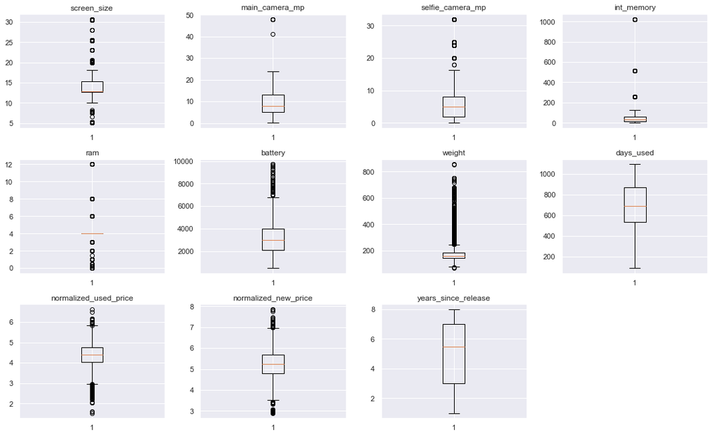

```
Wall time: 959 ms
```

```python
%%time

num_cols = df.select_dtypes(include=np.number).columns.tolist()

plt.figure(figsize=(15, 12))

for i, variable in enumerate(num_cols):
    plt.subplot(4, 4, i + 1)
    plt.boxplot(df[variable], whis=1.5)
    plt.tight_layout()
    plt.title(variable)

plt.show()

# Code from Hands_on_Notebook_ExploratoryDataAnalysis.ipynb section 4.5
# I added the time command since I wanted to know this commands execution time
```

### Outlier Treatment

The data contains information on two types of devices: cell phones and tablets.

Before looking at the data, the following axiom needs to be made: cell phones are not the same as tablets

They have different feature/functions and different primary use cases:

- Cell phones are primarily used for communication
- Tablets are primarily used to run applications  
  There are a number of references on the internet to support this:
- Difference Between Tablet and Smartphone
  - http://www.differencebetween.net/object/gadgets-object/difference-between-tablet-and-smartphone/
  - The conclusion:
    - Tablets have much larger screens than smartphones
    - Smartphones are more portable than tablets
    - Smartphones have call and SMS functionalities while many tablets do not
    - Some applications may only run in tablets and not smartphones
    - Smartphones have both WiFi and 3G while only some tablet models have both
- 18 Reasons Why Tablets are Better than your Smartphones
  - https://www.rswebsols.com/tutorials/technology/reasons-tablets-better-smartphones
  - Conclusion

    ```
      * Tablets have always held a peculiar charm that is hard to resist. Albeit, some of their features might  be there (sometimes) on some smartphones. But it would be ridiculous to equate smartphones with tablets.
    ```

In addition, the data also shows the following:

- 34 brands
  - The largest brand is "Other"
- 3454 devices
- 4 operating systems
- 50% of the devices released between 2013-2015
  - In technology terms, these are very old devices

Besides having so many brands and devices, there is also the number of years: 8. Eight years when dealing with cell phones and tablets is at least two generations of technology and coming very close to three. As most companies replace their IT technology, which includes cell phones and tablets, every three years, the devices are at least two replacement cycles back and almost three.

Furthermore when looking at the years, these were the most popular cell phones in 2013:

- Apple iPhone 5
- Blackberry Z30
- Motorola Moto X

In 2020, the most popular cell phones were:

- Samsung Galaxy A51
- Samsung Galaxy A71
- Xiaomi Redmi Note 9 Pro
- Samsung Galaxy S20 Ultra 5G
- Apple iPhone 12 Pro Max

The 2013 and 2020 phones are not even close to each other in terms of feature/functions. In addition, Blackberry does not make devices anymore.

Another interesting point is dual camera phones, or phones with selfie cameras, did not appear on the market in mass until 2016. See: https://thesmartphonephotographer.com/do-smartphones-really-need-multiple-cameras/

If the outliers for selfie cameras where treated, then the statistics for at least 50% of the phones would be affected. As stated before, 50% of the phones were released between 2013 and 2015.

The features/functions available in 2020 cell phones are vastly different from features/functions available in 2013. This also equally applies to tablets. What was available in 2013 is vastly different from 2020. I have even seen this myself with the phones and laptops I used then and am using now. There is really no comparison between what was available in 2013 and what is available now. This means there will be outliers.

In addition to there being a large difference between features/functions over the given 8 years, there is also a difference in the cost of the devices even in a giving calendar year. Cell phones can cost from $80 (AT&T site: AT&TFusion Z) to $1800 (AT&T site: SamsungGalaxy Z Fold3 5G). The same is also true for tablets which can cost from $200 (AT&T site: SamsungGalaxy Tab A7 Lite) to $1300 (AT&T site: AppleiPad Pro 12.9-inch (2021)). With differences in price comes differences in features/functions. The more expensive models will have more "bells and whisles". This means there will be outliers.

#### Conclusion

Given the inherent differnce between cell phones and tablets, number of brands, the number of devices, and the evolution of the technology, the logical conclusion is that there exists a wide difference in the features/functions available in cell phones and tablets over the given years of 2013 to 2020. As such, the outliers should not be treated and kept as is as they reflect the technology available at the time of release and the inherent difference between the devices. Treating the outliers will affect the skew of the data negatively affect the correlation.

The decision is to proceed with the data as-is.

```python
# Making backup copy of dataframe

df.to_csv("C:/Users/David/temp/used_device_data_transformed.csv", index=False)


# Read command if needed
# df = pd.read_csv("C:/Users/David/temp/used_device_data_transformed.csv")
```

## EDA

- It is a good idea to explore the data once again after manipulating it.

```python
branddf = pd.DataFrame(columns=["Number of Devices", "Percentage"])
branddf["Number of Devices"] = df["brand_name"].value_counts()
branddf["Percentage"] = df["brand_name"].value_counts(normalize=True)

print("Number of devices by brand with percentage of total \n")
print(branddf)

del branddf  # free memory
```

```
Number of devices by brand with percentage of total

            Number of Devices  Percentage
Others                    502    0.145339
Samsung                   341    0.098726
Huawei                    251    0.072669
LG                        201    0.058193
Lenovo                    171    0.049508
ZTE                       140    0.040533
Xiaomi                    132    0.038217
Oppo                      129    0.037348
Asus                      122    0.035321
Alcatel                   121    0.035032
Vivo                      117    0.033874
Micromax                  117    0.033874
Honor                     116    0.033584
HTC                       110    0.031847
Nokia                     106    0.030689
Motorola                  106    0.030689
Sony                       86    0.024899
Meizu                      62    0.017950
Gionee                     56    0.016213
Acer                       51    0.014765
XOLO                       49    0.014186
Panasonic                  47    0.013607
Realme                     41    0.011870
Apple                      39    0.011291
Lava                       36    0.010423
Celkon                     33    0.009554
Spice                      30    0.008686
Karbonn                    29    0.008396
Microsoft                  22    0.006369
OnePlus                    22    0.006369
Coolpad                    22    0.006369
BlackBerry                 22    0.006369
Google                     15    0.004343
Infinix                    10    0.002895
```

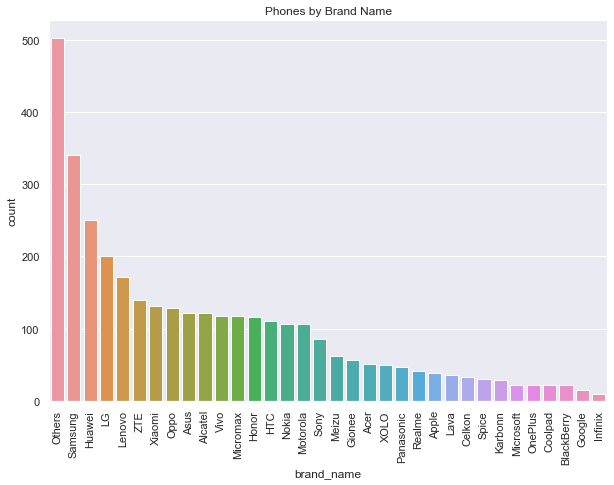

```python
plt.figure(figsize=(10, 7))
plt.title("Phones by Brand Name")
plt.xlabel("Brand Name")
sns.countplot(data=df, x="brand_name", order=df["brand_name"].value_counts().index)
plt.xticks(rotation=90)
```

```python
opsysdf = pd.DataFrame(columns=["Number", "Percentage"])
opsysdf["Number"] = df["os"].value_counts()
opsysdf["Percentage"] = df["os"].value_counts(normalize=True)

print("Operating system totals with percentage of total \n")
print(opsysdf)

del opsysdf  # free memory
```

```
Operating system totals with percentage of total

         Number  Percentage
Android    3214    0.930515
Others      137    0.039664
Windows      67    0.019398
iOS          36    0.010423
```

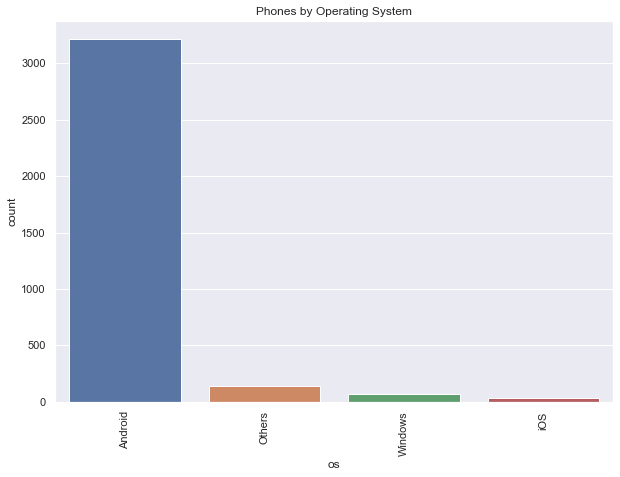

```python
plt.figure(figsize=(10, 7))
plt.title("Phones by Operating System")
plt.xlabel("Operating System")
sns.countplot(data=df, x="os", order=df["os"].value_counts().index)
plt.xticks(rotation=90)
```

```python
netdf = pd.DataFrame(
    columns=["4g Number", "4g Percentage", "5g Number", "5g Percentage"]
)
netdf["4g Number"] = df["4g"].value_counts()
netdf["4g Percentage"] = df["4g"].value_counts(normalize=True)
netdf["5g Number"] = df["5g"].value_counts()
netdf["5g Percentage"] = df["5g"].value_counts(normalize=True)

print("Network type totals with percentages \n")
print(netdf)

count4 = netdf.iloc[0, 0]
count5 = netdf.iloc[0, 2]

del netdf  # free memory
```

```
Network type totals with percentages

     4g Number  4g Percentage  5g Number  5g Percentage
yes       2335       0.676028        152       0.044007
no        1119       0.323972       3302       0.955993
```

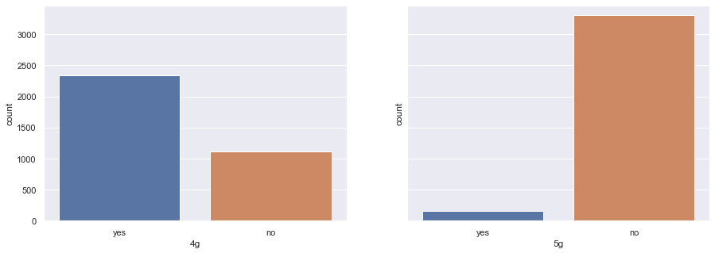

```python
fig, ax = plt.subplots(1, 2, figsize=(15, 5), sharey=True)
sns.countplot(df["4g"], ax=ax[0], order=["yes", "no"])
sns.countplot(df["5g"], ax=ax[1], order=["yes", "no"])
fig.show()
```

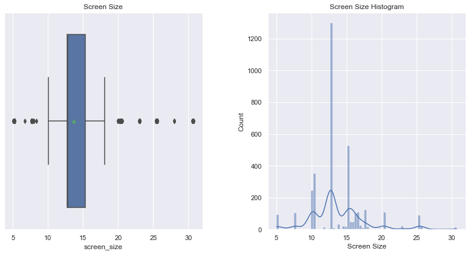

```python
plt.figure(figsize=(17, 6))

plt.subplot(131)
plt.title("Screen Size")
plt.xlabel("Screen Size")
sns.boxplot(data=df, x="screen_size", showmeans=True)

plt.subplot(132)
plt.title("Screen Size Histogram")
plt.xlabel("Screen Size")
sns.histplot(data=df, x="screen_size", kde=True)

plt.tight_layout(w_pad=5)
```

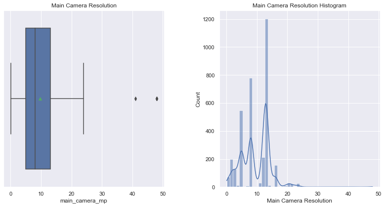

```python
plt.figure(figsize=(17, 6))

plt.subplot(131)
plt.title("Main Camera Resolution")
plt.xlabel("Main Camera Resolution")
sns.boxplot(data=df, x="main_camera_mp", showmeans=True)

plt.subplot(132)
plt.title("Main Camera Resolution Histogram")
plt.xlabel("Main Camera Resolution")
sns.histplot(data=df, x="main_camera_mp", kde=True)

plt.tight_layout(w_pad=5)
```